# Risk Factor Analysis

## Outcome Variable

**Outcome Variable:** wast_rec90d

## Predictor Variables

**Intervention Variable:** earlybf

**Adjustment Set:**

- arm
- sex
- W_mage
- meducyrs
- feducyrs
- hhwealth_quart
- hfoodsec
- W_mhtcm
- vagbrth
- W_birthwt
- W_birthlen
- W_nrooms
- W_nchldlt5
- brthmon
- W_parity
- impfloor
- impsan
- safeh20
- delta_W_mage
- delta_meducyrs
- delta_feducyrs
- delta_hhwealth_quart
- delta_hfoodsec
- delta_W_mhtcm
- delta_vagbrth
- delta_W_birthwt
- delta_W_birthlen
- delta_W_nrooms
- delta_W_nchldlt5
- delta_brthmon
- delta_W_parity
- delta_impfloor
- delta_impsan
- delta_safeh20

## Stratifying Variables

The analysis was stratified on these variable(s):

- agecat
- studyid
- country

## Data Summary

| agecat | studyid | country | earlybf | wast_rec90d | n_cell | n |
| --- | --- | --- | --- | --- | --- | --- |
| 0-24 months | ki0047075b-MAL-ED | BANGLADESH | 0 | 0 | 18 | 122 |
| 0-24 months | ki0047075b-MAL-ED | BANGLADESH | 0 | 1 | 32 | 122 |
| 0-24 months | ki0047075b-MAL-ED | BANGLADESH | 1 | 0 | 26 | 122 |
| 0-24 months | ki0047075b-MAL-ED | BANGLADESH | 1 | 1 | 46 | 122 |
| 0-24 months | ki0047075b-MAL-ED | BRAZIL | 0 | 0 | 3 | 23 |
| 0-24 months | ki0047075b-MAL-ED | BRAZIL | 0 | 1 | 12 | 23 |
| 0-24 months | ki0047075b-MAL-ED | BRAZIL | 1 | 0 | 3 | 23 |
| 0-24 months | ki0047075b-MAL-ED | BRAZIL | 1 | 1 | 5 | 23 |
| 0-24 months | ki0047075b-MAL-ED | INDIA | 0 | 0 | 27 | 178 |
| 0-24 months | ki0047075b-MAL-ED | INDIA | 0 | 1 | 45 | 178 |
| 0-24 months | ki0047075b-MAL-ED | INDIA | 1 | 0 | 44 | 178 |
| 0-24 months | ki0047075b-MAL-ED | INDIA | 1 | 1 | 62 | 178 |
| 0-24 months | ki0047075b-MAL-ED | NEPAL | 0 | 0 | 11 | 93 |
| 0-24 months | ki0047075b-MAL-ED | NEPAL | 0 | 1 | 40 | 93 |
| 0-24 months | ki0047075b-MAL-ED | NEPAL | 1 | 0 | 9 | 93 |
| 0-24 months | ki0047075b-MAL-ED | NEPAL | 1 | 1 | 33 | 93 |
| 0-24 months | ki0047075b-MAL-ED | PERU | 0 | 0 | 1 | 34 |
| 0-24 months | ki0047075b-MAL-ED | PERU | 0 | 1 | 3 | 34 |
| 0-24 months | ki0047075b-MAL-ED | PERU | 1 | 0 | 5 | 34 |
| 0-24 months | ki0047075b-MAL-ED | PERU | 1 | 1 | 25 | 34 |
| 0-24 months | ki0047075b-MAL-ED | SOUTH AFRICA | 0 | 0 | 6 | 80 |
| 0-24 months | ki0047075b-MAL-ED | SOUTH AFRICA | 0 | 1 | 24 | 80 |
| 0-24 months | ki0047075b-MAL-ED | SOUTH AFRICA | 1 | 0 | 8 | 80 |
| 0-24 months | ki0047075b-MAL-ED | SOUTH AFRICA | 1 | 1 | 42 | 80 |
| 0-24 months | ki0047075b-MAL-ED | TANZANIA, UNITED REPUBLIC OF | 0 | 0 | 2 | 45 |
| 0-24 months | ki0047075b-MAL-ED | TANZANIA, UNITED REPUBLIC OF | 0 | 1 | 2 | 45 |
| 0-24 months | ki0047075b-MAL-ED | TANZANIA, UNITED REPUBLIC OF | 1 | 0 | 6 | 45 |
| 0-24 months | ki0047075b-MAL-ED | TANZANIA, UNITED REPUBLIC OF | 1 | 1 | 35 | 45 |
| 0-24 months | ki1000109-EE | PAKISTAN | 0 | 0 | 254 | 514 |
| 0-24 months | ki1000109-EE | PAKISTAN | 0 | 1 | 186 | 514 |

[output cut: 138 more lines]

The following strata were considered:

- agecat: 0-24 months, studyid: ki0047075b-MAL-ED, country: BANGLADESH
- agecat: 0-24 months, studyid: ki0047075b-MAL-ED, country: BRAZIL
- agecat: 0-24 months, studyid: ki0047075b-MAL-ED, country: INDIA
- agecat: 0-24 months, studyid: ki0047075b-MAL-ED, country: NEPAL
- agecat: 0-24 months, studyid: ki0047075b-MAL-ED, country: PERU
- agecat: 0-24 months, studyid: ki0047075b-MAL-ED, country: SOUTH AFRICA
- agecat: 0-24 months, studyid: ki0047075b-MAL-ED, country: TANZANIA, UNITED REPUBLIC OF
- agecat: 0-24 months, studyid: ki1000109-EE, country: PAKISTAN
- agecat: 0-24 months, studyid: ki1000304b-SAS-CompFeed, country: INDIA
- agecat: 0-24 months, studyid: ki1017093c-NIH-Crypto, country: BANGLADESH
- agecat: 0-24 months, studyid: ki1113344-GMS-Nepal, country: NEPAL
- agecat: 0-24 months, studyid: ki1126311-ZVITAMBO, country: ZIMBABWE
- agecat: 0-24 months, studyid: kiGH5241-JiVitA-3, country: BANGLADESH
- agecat: 0-24 months, studyid: kiGH5241-JiVitA-4, country: BANGLADESH
- agecat: 0-6 months, studyid: ki0047075b-MAL-ED, country: BANGLADESH
- agecat: 0-6 months, studyid: ki0047075b-MAL-ED, country: BRAZIL
- agecat: 0-6 months, studyid: ki0047075b-MAL-ED, country: INDIA
- agecat: 0-6 months, studyid: ki0047075b-MAL-ED, country: NEPAL
- agecat: 0-6 months, studyid: ki0047075b-MAL-ED, country: PERU
- agecat: 0-6 months, studyid: ki0047075b-MAL-ED, country: SOUTH AFRICA
- agecat: 0-6 months, studyid: ki0047075b-MAL-ED, country: TANZANIA, UNITED REPUBLIC OF
- agecat: 0-6 months, studyid: ki1000109-EE, country: PAKISTAN
- agecat: 0-6 months, studyid: ki1000304b-SAS-CompFeed, country: INDIA
- agecat: 0-6 months, studyid: ki1017093c-NIH-Crypto, country: BANGLADESH
- agecat: 0-6 months, studyid: ki1113344-GMS-Nepal, country: NEPAL
- agecat: 0-6 months, studyid: ki1126311-ZVITAMBO, country: ZIMBABWE
- agecat: 0-6 months, studyid: kiGH5241-JiVitA-3, country: BANGLADESH
- agecat: 0-6 months, studyid: kiGH5241-JiVitA-4, country: BANGLADESH
- agecat: 6-24 months, studyid: ki0047075b-MAL-ED, country: BANGLADESH
- agecat: 6-24 months, studyid: ki0047075b-MAL-ED, country: BRAZIL
- agecat: 6-24 months, studyid: ki0047075b-MAL-ED, country: INDIA
- agecat: 6-24 months, studyid: ki0047075b-MAL-ED, country: NEPAL
- agecat: 6-24 months, studyid: ki0047075b-MAL-ED, country: PERU
- agecat: 6-24 months, studyid: ki0047075b-MAL-ED, country: SOUTH AFRICA
- agecat: 6-24 months, studyid: ki0047075b-MAL-ED, country: TANZANIA, UNITED REPUBLIC OF
- agecat: 6-24 months, studyid: ki1000109-EE, country: PAKISTAN
- agecat: 6-24 months, studyid: ki1000304b-SAS-CompFeed, country: INDIA
- agecat: 6-24 months, studyid: ki1017093c-NIH-Crypto, country: BANGLADESH
- agecat: 6-24 months, studyid: ki1113344-GMS-Nepal, country: NEPAL
- agecat: 6-24 months, studyid: ki1126311-ZVITAMBO, country: ZIMBABWE
- agecat: 6-24 months, studyid: kiGH5241-JiVitA-3, country: BANGLADESH
- agecat: 6-24 months, studyid: kiGH5241-JiVitA-4, country: BANGLADESH

### Dropped Strata

Some strata were dropped due to rare outcomes:

- agecat: 0-24 months, studyid: ki0047075b-MAL-ED, country: BRAZIL
- agecat: 0-24 months, studyid: ki0047075b-MAL-ED, country: PERU
- agecat: 0-24 months, studyid: ki0047075b-MAL-ED, country: TANZANIA, UNITED REPUBLIC OF
- agecat: 0-6 months, studyid: ki0047075b-MAL-ED, country: BRAZIL
- agecat: 0-6 months, studyid: ki0047075b-MAL-ED, country: NEPAL
- agecat: 0-6 months, studyid: ki0047075b-MAL-ED, country: PERU
- agecat: 0-6 months, studyid: ki0047075b-MAL-ED, country: SOUTH AFRICA
- agecat: 0-6 months, studyid: ki0047075b-MAL-ED, country: TANZANIA, UNITED REPUBLIC OF
- agecat: 6-24 months, studyid: ki0047075b-MAL-ED, country: BRAZIL
- agecat: 6-24 months, studyid: ki0047075b-MAL-ED, country: NEPAL
- agecat: 6-24 months, studyid: ki0047075b-MAL-ED, country: PERU
- agecat: 6-24 months, studyid: ki0047075b-MAL-ED, country: SOUTH AFRICA
- agecat: 6-24 months, studyid: ki0047075b-MAL-ED, country: TANZANIA, UNITED REPUBLIC OF
- agecat: 6-24 months, studyid: ki1017093c-NIH-Crypto, country: BANGLADESH
- agecat: 6-24 months, studyid: kiGH5241-JiVitA-3, country: BANGLADESH

## Methods Detail

We’re interested in the causal parameters $E[Y_a]$ for all values of $a \in \mathcal{A}$. These parameters represent the mean outcome if, possibly contrary to fact, we intervened to set all units to have $A=a$. Under the randomization and positivity assumptions, these are identified by the statistical parameters $\psi_a=E_W[E_{Y|A,W}(Y|A=a,W)]$. In addition, we’re interested in the mean of $Y$, $E[Y]$ under no intervention (the observed mean). We will estimate these parameters by using SuperLearner to fit the relevant likelihood factors – $E_{Y|A,W}(Y|A=a,W)$ and $p(A=a|W)$, and then updating our likelihood fit using a joint TMLE.

For unadjusted analyses ($W=\{\}$), initial likelihoods were estimated using Lrnr_glm to estimate the simple $E(Y|A)$ and Lrnr_mean to estimate $p(A)$. For adjusted analyses, a small library containing Lrnr_glmnet, Lrnr_xgboost, and Lrnr_mean was used.

Having estimated these parameters, we will then use the delta method to estimate relative risks and attributable risks relative to a prespecified baseline level of $A$.

# Results Detail

## Results Plots

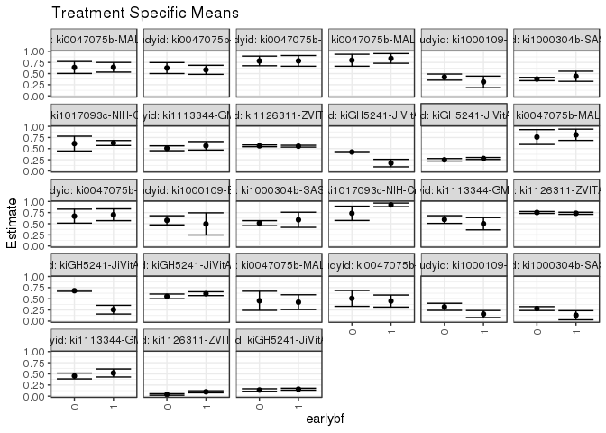

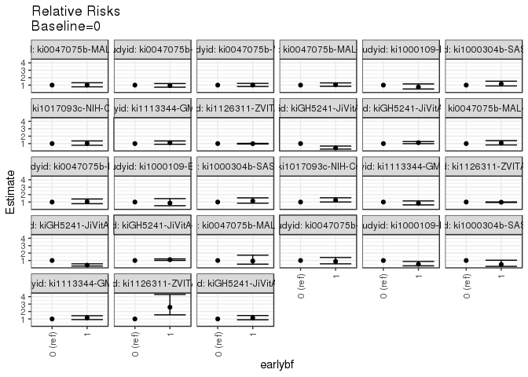

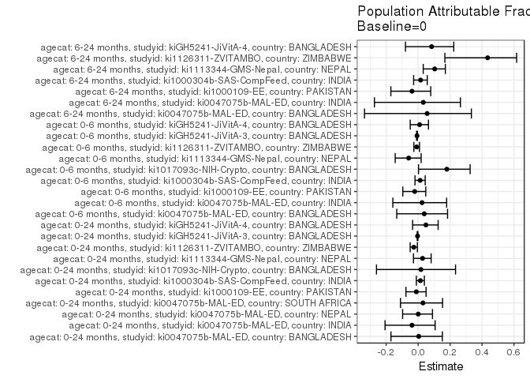

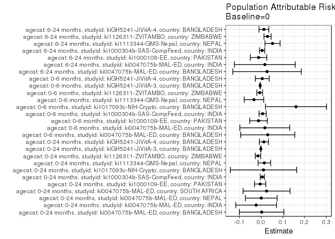

## Results Table

### Parameter: TSM

| agecat | studyid | country | intervention_level | baseline_level | estimate | ci_lower | ci_upper |
| --- | --- | --- | --- | --- | --- | --- | --- |
| 0-24 months | ki0047075b-MAL-ED | BANGLADESH | 0 | NA | 0.6369250 | 0.5029019 | 0.7709480 |
| 0-24 months | ki0047075b-MAL-ED | BANGLADESH | 1 | NA | 0.6411943 | 0.5322900 | 0.7500987 |
| 0-24 months | ki0047075b-MAL-ED | INDIA | 0 | NA | 0.6241879 | 0.5008158 | 0.7475601 |
| 0-24 months | ki0047075b-MAL-ED | INDIA | 1 | NA | 0.5849494 | 0.4835414 | 0.6863573 |
| 0-24 months | ki0047075b-MAL-ED | NEPAL | 0 | NA | 0.7843137 | 0.6765475 | 0.8920799 |
| 0-24 months | ki0047075b-MAL-ED | NEPAL | 1 | NA | 0.7857143 | 0.6655613 | 0.9058673 |
| 0-24 months | ki0047075b-MAL-ED | SOUTH AFRICA | 0 | NA | 0.8000000 | 0.6657395 | 0.9342605 |
| 0-24 months | ki0047075b-MAL-ED | SOUTH AFRICA | 1 | NA | 0.8400000 | 0.7318211 | 0.9481789 |
| 0-24 months | ki1000109-EE | PAKISTAN | 0 | NA | 0.4210098 | 0.3519634 | 0.4900561 |
| 0-24 months | ki1000109-EE | PAKISTAN | 1 | NA | 0.3129273 | 0.1830884 | 0.4427662 |
| 0-24 months | ki1000304b-SAS-CompFeed | INDIA | 0 | NA | 0.3772301 | 0.3408966 | 0.4135636 |
| 0-24 months | ki1000304b-SAS-CompFeed | INDIA | 1 | NA | 0.4391038 | 0.3257827 | 0.5524249 |
| 0-24 months | ki1017093c-NIH-Crypto | BANGLADESH | 0 | NA | 0.6128712 | 0.4469487 | 0.7787938 |
| 0-24 months | ki1017093c-NIH-Crypto | BANGLADESH | 1 | NA | 0.6264154 | 0.5705115 | 0.6823193 |
| 0-24 months | ki1113344-GMS-Nepal | NEPAL | 0 | NA | 0.5082486 | 0.4536404 | 0.5628567 |
| 0-24 months | ki1113344-GMS-Nepal | NEPAL | 1 | NA | 0.5634024 | 0.4681896 | 0.6586152 |
| 0-24 months | ki1126311-ZVITAMBO | ZIMBABWE | 0 | NA | 0.5620128 | 0.5416383 | 0.5823874 |
| 0-24 months | ki1126311-ZVITAMBO | ZIMBABWE | 1 | NA | 0.5545514 | 0.5337965 | 0.5753064 |
| 0-24 months | kiGH5241-JiVitA-3 | BANGLADESH | 0 | NA | 0.4244296 | 0.4132640 | 0.4355952 |
| 0-24 months | kiGH5241-JiVitA-3 | BANGLADESH | 1 | NA | 0.1751727 | 0.0913198 | 0.2590255 |
| 0-24 months | kiGH5241-JiVitA-4 | BANGLADESH | 0 | NA | 0.2491039 | 0.2211252 | 0.2770826 |
| 0-24 months | kiGH5241-JiVitA-4 | BANGLADESH | 1 | NA | 0.2792302 | 0.2569007 | 0.3015598 |
| 0-6 months | ki0047075b-MAL-ED | BANGLADESH | 0 | NA | 0.7600000 | 0.5939976 | 0.9260024 |
| 0-6 months | ki0047075b-MAL-ED | BANGLADESH | 1 | NA | 0.8108108 | 0.6847315 | 0.9368901 |
| 0-6 months | ki0047075b-MAL-ED | INDIA | 0 | NA | 0.6698293 | 0.5124334 | 0.8272251 |
| 0-6 months | ki0047075b-MAL-ED | INDIA | 1 | NA | 0.7009210 | 0.5686351 | 0.8332068 |
| 0-6 months | ki1000109-EE | PAKISTAN | 0 | NA | 0.5769404 | 0.4745845 | 0.6792964 |
| 0-6 months | ki1000109-EE | PAKISTAN | 1 | NA | 0.4959280 | 0.2467875 | 0.7450685 |
| 0-6 months | ki1000304b-SAS-CompFeed | INDIA | 0 | NA | 0.5125539 | 0.4564304 | 0.5686774 |
| 0-6 months | ki1000304b-SAS-CompFeed | INDIA | 1 | NA | 0.5883076 | 0.4186317 | 0.7579836 |
| 0-6 months | ki1017093c-NIH-Crypto | BANGLADESH | 0 | NA | 0.7333333 | 0.5730670 | 0.8935997 |
| 0-6 months | ki1017093c-NIH-Crypto | BANGLADESH | 1 | NA | 0.9226190 | 0.8817191 | 0.9635190 |
| 0-6 months | ki1113344-GMS-Nepal | NEPAL | 0 | NA | 0.5941174 | 0.5074819 | 0.6807529 |
| 0-6 months | ki1113344-GMS-Nepal | NEPAL | 1 | NA | 0.4997707 | 0.3626947 | 0.6368468 |
| 0-6 months | ki1126311-ZVITAMBO | ZIMBABWE | 0 | NA | 0.7526715 | 0.7312305 | 0.7741124 |
| 0-6 months | ki1126311-ZVITAMBO | ZIMBABWE | 1 | NA | 0.7347815 | 0.7116999 | 0.7578630 |
| 0-6 months | kiGH5241-JiVitA-3 | BANGLADESH | 0 | NA | 0.6810572 | 0.6677052 | 0.6944093 |
| 0-6 months | kiGH5241-JiVitA-3 | BANGLADESH | 1 | NA | 0.2566514 | 0.1586535 | 0.3546494 |
| 0-6 months | kiGH5241-JiVitA-4 | BANGLADESH | 0 | NA | 0.5535470 | 0.5008113 | 0.6062828 |
| 0-6 months | kiGH5241-JiVitA-4 | BANGLADESH | 1 | NA | 0.6146877 | 0.5715360 | 0.6578393 |
| 6-24 months | ki0047075b-MAL-ED | BANGLADESH | 0 | NA | 0.4560330 | 0.2422408 | 0.6698253 |
| 6-24 months | ki0047075b-MAL-ED | BANGLADESH | 1 | NA | 0.4248110 | 0.2595660 | 0.5900561 |
| 6-24 months | ki0047075b-MAL-ED | INDIA | 0 | NA | 0.5092748 | 0.3316121 | 0.6869375 |
| 6-24 months | ki0047075b-MAL-ED | INDIA | 1 | NA | 0.4491754 | 0.3142481 | 0.5841027 |
| 6-24 months | ki1000109-EE | PAKISTAN | 0 | NA | 0.3205539 | 0.2415810 | 0.3995269 |
| 6-24 months | ki1000109-EE | PAKISTAN | 1 | NA | 0.1586753 | 0.0795522 | 0.2377985 |
| 6-24 months | ki1000304b-SAS-CompFeed | INDIA | 0 | NA | 0.2810042 | 0.2378176 | 0.3241909 |
| 6-24 months | ki1000304b-SAS-CompFeed | INDIA | 1 | NA | 0.1321497 | 0.0295344 | 0.2347650 |
| 6-24 months | ki1113344-GMS-Nepal | NEPAL | 0 | NA | 0.4520374 | 0.3867452 | 0.5173296 |
| 6-24 months | ki1113344-GMS-Nepal | NEPAL | 1 | NA | 0.5191152 | 0.4291712 | 0.6090593 |
| 6-24 months | ki1126311-ZVITAMBO | ZIMBABWE | 0 | NA | 0.0381558 | 0.0209602 | 0.0553514 |
| 6-24 months | ki1126311-ZVITAMBO | ZIMBABWE | 1 | NA | 0.0985268 | 0.0753059 | 0.1217476 |
| 6-24 months | kiGH5241-JiVitA-4 | BANGLADESH | 0 | NA | 0.1379812 | 0.1097074 | 0.1662550 |
| 6-24 months | kiGH5241-JiVitA-4 | BANGLADESH | 1 | NA | 0.1572383 | 0.1358827 | 0.1785939 |

### Parameter: E(Y)

| agecat | studyid | country | intervention_level | baseline_level | estimate | ci_lower | ci_upper |
| --- | --- | --- | --- | --- | --- | --- | --- |
| 0-24 months | ki0047075b-MAL-ED | BANGLADESH | NA | NA | 0.6393443 | 0.5524803 | 0.7262082 |
| 0-24 months | ki0047075b-MAL-ED | INDIA | NA | NA | 0.6011236 | 0.5212729 | 0.6809743 |
| 0-24 months | ki0047075b-MAL-ED | NEPAL | NA | NA | 0.7849462 | 0.7049947 | 0.8648978 |
| 0-24 months | ki0047075b-MAL-ED | SOUTH AFRICA | NA | NA | 0.8250000 | 0.7407860 | 0.9092140 |
| 0-24 months | ki1000109-EE | PAKISTAN | NA | NA | 0.4163424 | 0.3511349 | 0.4815500 |
| 0-24 months | ki1000304b-SAS-CompFeed | INDIA | NA | NA | 0.3827160 | 0.3474971 | 0.4179350 |
| 0-24 months | ki1017093c-NIH-Crypto | BANGLADESH | NA | NA | 0.6237942 | 0.5698223 | 0.6777662 |
| 0-24 months | ki1113344-GMS-Nepal | NEPAL | NA | NA | 0.5227723 | 0.4753649 | 0.5701796 |
| 0-24 months | ki1126311-ZVITAMBO | ZIMBABWE | NA | NA | 0.5472806 | 0.5299898 | 0.5645714 |
| 0-24 months | kiGH5241-JiVitA-3 | BANGLADESH | NA | NA | 0.4229803 | 0.4118532 | 0.4341074 |
| 0-24 months | kiGH5241-JiVitA-4 | BANGLADESH | NA | NA | 0.2618872 | 0.2425585 | 0.2812158 |
| 0-6 months | ki0047075b-MAL-ED | BANGLADESH | NA | NA | 0.7903226 | 0.6894772 | 0.8911679 |
| 0-6 months | ki0047075b-MAL-ED | INDIA | NA | NA | 0.6867470 | 0.5837430 | 0.7897510 |
| 0-6 months | ki1000109-EE | PAKISTAN | NA | NA | 0.5648148 | 0.4692893 | 0.6603404 |
| 0-6 months | ki1000304b-SAS-CompFeed | INDIA | NA | NA | 0.5192878 | 0.4654446 | 0.5731311 |
| 0-6 months | ki1017093c-NIH-Crypto | BANGLADESH | NA | NA | 0.8939394 | 0.8505280 | 0.9373508 |
| 0-6 months | ki1113344-GMS-Nepal | NEPAL | NA | NA | 0.5609756 | 0.4845156 | 0.6374356 |
| 0-6 months | ki1126311-ZVITAMBO | ZIMBABWE | NA | NA | 0.7460664 | 0.7282412 | 0.7638917 |
| 0-6 months | kiGH5241-JiVitA-3 | BANGLADESH | NA | NA | 0.6764644 | 0.6631306 | 0.6897982 |
| 0-6 months | kiGH5241-JiVitA-4 | BANGLADESH | NA | NA | 0.5587703 | 0.5173487 | 0.6001920 |
| 6-24 months | ki0047075b-MAL-ED | BANGLADESH | NA | NA | 0.4833333 | 0.3508378 | 0.6158289 |
| 6-24 months | ki0047075b-MAL-ED | INDIA | NA | NA | 0.5263158 | 0.4116286 | 0.6410029 |
| 6-24 months | ki1000109-EE | PAKISTAN | NA | NA | 0.3087248 | 0.2336906 | 0.3837591 |
| 6-24 months | ki1000304b-SAS-CompFeed | INDIA | NA | NA | 0.2854123 | 0.2436284 | 0.3271961 |
| 6-24 months | ki1113344-GMS-Nepal | NEPAL | NA | NA | 0.5043988 | 0.4461732 | 0.5626244 |
| 6-24 months | ki1126311-ZVITAMBO | ZIMBABWE | NA | NA | 0.0675105 | 0.0516864 | 0.0833347 |
| 6-24 months | kiGH5241-JiVitA-4 | BANGLADESH | NA | NA | 0.1506942 | 0.1331077 | 0.1682807 |

### Parameter: RR

| agecat | studyid | country | intervention_level | baseline_level | estimate | ci_lower | ci_upper |
| --- | --- | --- | --- | --- | --- | --- | --- |
| 0-24 months | ki0047075b-MAL-ED | BANGLADESH | 0 | 0 | 1.0000000 | 1.0000000 | 1.0000000 |
| 0-24 months | ki0047075b-MAL-ED | BANGLADESH | 1 | 0 | 1.0067031 | 0.7681566 | 1.3193288 |
| 0-24 months | ki0047075b-MAL-ED | INDIA | 0 | 0 | 1.0000000 | 1.0000000 | 1.0000000 |
| 0-24 months | ki0047075b-MAL-ED | INDIA | 1 | 0 | 0.9371366 | 0.7236047 | 1.2136807 |
| 0-24 months | ki0047075b-MAL-ED | NEPAL | 0 | 0 | 1.0000000 | 1.0000000 | 1.0000000 |
| 0-24 months | ki0047075b-MAL-ED | NEPAL | 1 | 0 | 1.0017857 | 0.8150417 | 1.2313168 |
| 0-24 months | ki0047075b-MAL-ED | SOUTH AFRICA | 0 | 0 | 1.0000000 | 1.0000000 | 1.0000000 |
| 0-24 months | ki0047075b-MAL-ED | SOUTH AFRICA | 1 | 0 | 1.0500000 | 0.8496502 | 1.2975928 |
| 0-24 months | ki1000109-EE | PAKISTAN | 0 | 0 | 1.0000000 | 1.0000000 | 1.0000000 |
| 0-24 months | ki1000109-EE | PAKISTAN | 1 | 0 | 0.7432780 | 0.4765561 | 1.1592806 |
| 0-24 months | ki1000304b-SAS-CompFeed | INDIA | 0 | 0 | 1.0000000 | 1.0000000 | 1.0000000 |
| 0-24 months | ki1000304b-SAS-CompFeed | INDIA | 1 | 0 | 1.1640212 | 0.8873365 | 1.5269803 |
| 0-24 months | ki1017093c-NIH-Crypto | BANGLADESH | 0 | 0 | 1.0000000 | 1.0000000 | 1.0000000 |
| 0-24 months | ki1017093c-NIH-Crypto | BANGLADESH | 1 | 0 | 1.0220996 | 0.7704036 | 1.3560263 |
| 0-24 months | ki1113344-GMS-Nepal | NEPAL | 0 | 0 | 1.0000000 | 1.0000000 | 1.0000000 |
| 0-24 months | ki1113344-GMS-Nepal | NEPAL | 1 | 0 | 1.1085174 | 0.9073864 | 1.3542310 |
| 0-24 months | ki1126311-ZVITAMBO | ZIMBABWE | 0 | 0 | 1.0000000 | 1.0000000 | 1.0000000 |
| 0-24 months | ki1126311-ZVITAMBO | ZIMBABWE | 1 | 0 | 0.9867238 | 0.9440160 | 1.0313637 |
| 0-24 months | kiGH5241-JiVitA-3 | BANGLADESH | 0 | 0 | 1.0000000 | 1.0000000 | 1.0000000 |
| 0-24 months | kiGH5241-JiVitA-3 | BANGLADESH | 1 | 0 | 0.4127249 | 0.2555426 | 0.6665890 |
| 0-24 months | kiGH5241-JiVitA-4 | BANGLADESH | 0 | 0 | 1.0000000 | 1.0000000 | 1.0000000 |
| 0-24 months | kiGH5241-JiVitA-4 | BANGLADESH | 1 | 0 | 1.1209389 | 0.9885661 | 1.2710368 |
| 0-6 months | ki0047075b-MAL-ED | BANGLADESH | 0 | 0 | 1.0000000 | 1.0000000 | 1.0000000 |
| 0-6 months | ki0047075b-MAL-ED | BANGLADESH | 1 | 0 | 1.0668563 | 0.8159358 | 1.3949411 |
| 0-6 months | ki0047075b-MAL-ED | INDIA | 0 | 0 | 1.0000000 | 1.0000000 | 1.0000000 |
| 0-6 months | ki0047075b-MAL-ED | INDIA | 1 | 0 | 1.0464174 | 0.7765488 | 1.4100713 |
| 0-6 months | ki1000109-EE | PAKISTAN | 0 | 0 | 1.0000000 | 1.0000000 | 1.0000000 |
| 0-6 months | ki1000109-EE | PAKISTAN | 1 | 0 | 0.8595827 | 0.5061043 | 1.4599408 |
| 0-6 months | ki1000304b-SAS-CompFeed | INDIA | 0 | 0 | 1.0000000 | 1.0000000 | 1.0000000 |
| 0-6 months | ki1000304b-SAS-CompFeed | INDIA | 1 | 0 | 1.1477966 | 0.8445864 | 1.5598607 |
| 0-6 months | ki1017093c-NIH-Crypto | BANGLADESH | 0 | 0 | 1.0000000 | 1.0000000 | 1.0000000 |
| 0-6 months | ki1017093c-NIH-Crypto | BANGLADESH | 1 | 0 | 1.2581169 | 1.0066423 | 1.5724137 |
| 0-6 months | ki1113344-GMS-Nepal | NEPAL | 0 | 0 | 1.0000000 | 1.0000000 | 1.0000000 |
| 0-6 months | ki1113344-GMS-Nepal | NEPAL | 1 | 0 | 0.8411986 | 0.6171492 | 1.1465868 |
| 0-6 months | ki1126311-ZVITAMBO | ZIMBABWE | 0 | 0 | 1.0000000 | 1.0000000 | 1.0000000 |
| 0-6 months | ki1126311-ZVITAMBO | ZIMBABWE | 1 | 0 | 0.9762313 | 0.9398457 | 1.0140256 |
| 0-6 months | kiGH5241-JiVitA-3 | BANGLADESH | 0 | 0 | 1.0000000 | 1.0000000 | 1.0000000 |
| 0-6 months | kiGH5241-JiVitA-3 | BANGLADESH | 1 | 0 | 0.3768427 | 0.2571198 | 0.5523123 |
| 0-6 months | kiGH5241-JiVitA-4 | BANGLADESH | 0 | 0 | 1.0000000 | 1.0000000 | 1.0000000 |
| 0-6 months | kiGH5241-JiVitA-4 | BANGLADESH | 1 | 0 | 1.1104524 | 1.0136142 | 1.2165424 |
| 6-24 months | ki0047075b-MAL-ED | BANGLADESH | 0 | 0 | 1.0000000 | 1.0000000 | 1.0000000 |
| 6-24 months | ki0047075b-MAL-ED | BANGLADESH | 1 | 0 | 0.9315356 | 0.5063940 | 1.7136037 |
| 6-24 months | ki0047075b-MAL-ED | INDIA | 0 | 0 | 1.0000000 | 1.0000000 | 1.0000000 |
| 6-24 months | ki0047075b-MAL-ED | INDIA | 1 | 0 | 0.8819903 | 0.5537528 | 1.4047907 |
| 6-24 months | ki1000109-EE | PAKISTAN | 0 | 0 | 1.0000000 | 1.0000000 | 1.0000000 |
| 6-24 months | ki1000109-EE | PAKISTAN | 1 | 0 | 0.4950035 | 0.2820417 | 0.8687669 |
| 6-24 months | ki1000304b-SAS-CompFeed | INDIA | 0 | 0 | 1.0000000 | 1.0000000 | 1.0000000 |
| 6-24 months | ki1000304b-SAS-CompFeed | INDIA | 1 | 0 | 0.4702766 | 0.2135528 | 1.0356226 |
| 6-24 months | ki1113344-GMS-Nepal | NEPAL | 0 | 0 | 1.0000000 | 1.0000000 | 1.0000000 |
| 6-24 months | ki1113344-GMS-Nepal | NEPAL | 1 | 0 | 1.1483900 | 0.9167292 | 1.4385922 |
| 6-24 months | ki1126311-ZVITAMBO | ZIMBABWE | 0 | 0 | 1.0000000 | 1.0000000 | 1.0000000 |
| 6-24 months | ki1126311-ZVITAMBO | ZIMBABWE | 1 | 0 | 2.5822218 | 1.5537099 | 4.2915793 |
| 6-24 months | kiGH5241-JiVitA-4 | BANGLADESH | 0 | 0 | 1.0000000 | 1.0000000 | 1.0000000 |
| 6-24 months | kiGH5241-JiVitA-4 | BANGLADESH | 1 | 0 | 1.1395632 | 0.8911536 | 1.4572171 |

### Parameter: PAR

| agecat | studyid | country | intervention_level | baseline_level | estimate | ci_lower | ci_upper |
| --- | --- | --- | --- | --- | --- | --- | --- |
| 0-24 months | ki0047075b-MAL-ED | BANGLADESH | 0 | NA | 0.0024193 | -0.1000157 | 0.1048543 |
| 0-24 months | ki0047075b-MAL-ED | INDIA | 0 | NA | -0.0230643 | -0.1168355 | 0.0707068 |
| 0-24 months | ki0047075b-MAL-ED | NEPAL | 0 | NA | 0.0006325 | -0.0725325 | 0.0737975 |
| 0-24 months | ki0047075b-MAL-ED | SOUTH AFRICA | 0 | NA | 0.0250000 | -0.0833539 | 0.1333539 |
| 0-24 months | ki1000109-EE | PAKISTAN | 0 | NA | -0.0046674 | -0.0308266 | 0.0214919 |
| 0-24 months | ki1000304b-SAS-CompFeed | INDIA | 0 | NA | 0.0054860 | -0.0041069 | 0.0150788 |
| 0-24 months | ki1017093c-NIH-Crypto | BANGLADESH | 0 | NA | 0.0109230 | -0.1416563 | 0.1635023 |
| 0-24 months | ki1113344-GMS-Nepal | NEPAL | 0 | NA | 0.0145237 | -0.0143239 | 0.0433713 |
| 0-24 months | ki1126311-ZVITAMBO | ZIMBABWE | 0 | NA | -0.0147322 | -0.0269860 | -0.0024785 |
| 0-24 months | kiGH5241-JiVitA-3 | BANGLADESH | 0 | NA | -0.0014493 | -0.0024276 | -0.0004710 |
| 0-24 months | kiGH5241-JiVitA-4 | BANGLADESH | 0 | NA | 0.0127833 | -0.0081214 | 0.0336880 |
| 0-6 months | ki0047075b-MAL-ED | BANGLADESH | 0 | NA | 0.0303226 | -0.0943770 | 0.1550222 |
| 0-6 months | ki0047075b-MAL-ED | INDIA | 0 | NA | 0.0169177 | -0.0979807 | 0.1318161 |
| 0-6 months | ki1000109-EE | PAKISTAN | 0 | NA | -0.0121256 | -0.0525378 | 0.0282866 |
| 0-6 months | ki1000304b-SAS-CompFeed | INDIA | 0 | NA | 0.0067339 | -0.0098003 | 0.0232682 |
| 0-6 months | ki1017093c-NIH-Crypto | BANGLADESH | 0 | NA | 0.1606061 | 0.0199418 | 0.3012703 |
| 0-6 months | ki1113344-GMS-Nepal | NEPAL | 0 | NA | -0.0331418 | -0.0780846 | 0.0118010 |
| 0-6 months | ki1126311-ZVITAMBO | ZIMBABWE | 0 | NA | -0.0066050 | -0.0197206 | 0.0065105 |
| 0-6 months | kiGH5241-JiVitA-3 | BANGLADESH | 0 | NA | -0.0045929 | -0.0063892 | -0.0027966 |
| 0-6 months | kiGH5241-JiVitA-4 | BANGLADESH | 0 | NA | 0.0052233 | -0.0266737 | 0.0371203 |
| 6-24 months | ki0047075b-MAL-ED | BANGLADESH | 0 | NA | 0.0273003 | -0.1303049 | 0.1849055 |
| 6-24 months | ki0047075b-MAL-ED | INDIA | 0 | NA | 0.0170410 | -0.1228393 | 0.1569213 |
| 6-24 months | ki1000109-EE | PAKISTAN | 0 | NA | -0.0118291 | -0.0497251 | 0.0260669 |
| 6-24 months | ki1000304b-SAS-CompFeed | INDIA | 0 | NA | 0.0044080 | -0.0077517 | 0.0165677 |
| 6-24 months | ki1113344-GMS-Nepal | NEPAL | 0 | NA | 0.0523614 | 0.0175078 | 0.0872151 |
| 6-24 months | ki1126311-ZVITAMBO | ZIMBABWE | 0 | NA | 0.0293547 | 0.0129877 | 0.0457218 |
| 6-24 months | kiGH5241-JiVitA-4 | BANGLADESH | 0 | NA | 0.0127130 | -0.0099365 | 0.0353626 |

### Parameter: PAF

| agecat | studyid | country | intervention_level | baseline_level | estimate | ci_lower | ci_upper |
| --- | --- | --- | --- | --- | --- | --- | --- |
| 0-24 months | ki0047075b-MAL-ED | BANGLADESH | 0 | NA | 0.0037840 | -0.1700363 | 0.1517817 |
| 0-24 months | ki0047075b-MAL-ED | INDIA | 0 | NA | -0.0383687 | -0.2067650 | 0.1065290 |
| 0-24 months | ki0047075b-MAL-ED | NEPAL | 0 | NA | 0.0008058 | -0.0968894 | 0.0897997 |
| 0-24 months | ki0047075b-MAL-ED | SOUTH AFRICA | 0 | NA | 0.0303030 | -0.1102301 | 0.1530474 |
| 0-24 months | ki1000109-EE | PAKISTAN | 0 | NA | -0.0112104 | -0.0761530 | 0.0498131 |
| 0-24 months | ki1000304b-SAS-CompFeed | INDIA | 0 | NA | 0.0143343 | -0.0110634 | 0.0390939 |
| 0-24 months | ki1017093c-NIH-Crypto | BANGLADESH | 0 | NA | 0.0175106 | -0.2603915 | 0.2341384 |
| 0-24 months | ki1113344-GMS-Nepal | NEPAL | 0 | NA | 0.0277821 | -0.0289617 | 0.0813966 |
| 0-24 months | ki1126311-ZVITAMBO | ZIMBABWE | 0 | NA | -0.0269190 | -0.0496412 | -0.0046887 |
| 0-24 months | kiGH5241-JiVitA-3 | BANGLADESH | 0 | NA | -0.0034264 | -0.0057442 | -0.0011140 |
| 0-24 months | kiGH5241-JiVitA-4 | BANGLADESH | 0 | NA | 0.0488122 | -0.0344098 | 0.1253386 |
| 0-6 months | ki0047075b-MAL-ED | BANGLADESH | 0 | NA | 0.0383673 | -0.1336084 | 0.1842533 |
| 0-6 months | ki0047075b-MAL-ED | INDIA | 0 | NA | 0.0246346 | -0.1581066 | 0.1785405 |
| 0-6 months | ki1000109-EE | PAKISTAN | 0 | NA | -0.0214683 | -0.0958236 | 0.0478418 |
| 0-6 months | ki1000304b-SAS-CompFeed | INDIA | 0 | NA | 0.0129676 | -0.0194035 | 0.0443108 |
| 0-6 months | ki1017093c-NIH-Crypto | BANGLADESH | 0 | NA | 0.1796610 | 0.0024658 | 0.3253805 |
| 0-6 months | ki1113344-GMS-Nepal | NEPAL | 0 | NA | -0.0590788 | -0.1431898 | 0.0188436 |
| 0-6 months | ki1126311-ZVITAMBO | ZIMBABWE | 0 | NA | -0.0088531 | -0.0266019 | 0.0085888 |
| 0-6 months | kiGH5241-JiVitA-3 | BANGLADESH | 0 | NA | -0.0067895 | -0.0094595 | -0.0041266 |
| 0-6 months | kiGH5241-JiVitA-4 | BANGLADESH | 0 | NA | 0.0093478 | -0.0494309 | 0.0648344 |
| 6-24 months | ki0047075b-MAL-ED | BANGLADESH | 0 | NA | 0.0564834 | -0.3352870 | 0.3333092 |
| 6-24 months | ki0047075b-MAL-ED | INDIA | 0 | NA | 0.0323779 | -0.2732670 | 0.2646534 |
| 6-24 months | ki1000109-EE | PAKISTAN | 0 | NA | -0.0383160 | -0.1705313 | 0.0789651 |
| 6-24 months | ki1000304b-SAS-CompFeed | INDIA | 0 | NA | 0.0154444 | -0.0280910 | 0.0571362 |
| 6-24 months | ki1113344-GMS-Nepal | NEPAL | 0 | NA | 0.1038096 | 0.0319445 | 0.1703396 |
| 6-24 months | ki1126311-ZVITAMBO | ZIMBABWE | 0 | NA | 0.4348170 | 0.1674472 | 0.6163225 |
| 6-24 months | kiGH5241-JiVitA-4 | BANGLADESH | 0 | NA | 0.0843630 | -0.0790248 | 0.2230103 |